# FINAL_08_shelter-model

## Notebook #8 (final)

This is the final notebook created for the Simulation ISYE-6644 project.

Key features:

- models incoming clients arrival rate based on seasonality
- incorporates full client families (woman and children)
- incorporates variability of stay based on the condition of the victim (the various cases are detailed [here](https://github.com/sim-team-z/learning-simpy#readme)
- models undisclosed hotel accomodation for life threatening cases
- very flexible. Allows modifying # of simulation runs, duration of simulation, weight of incoming client case-type, arrival rates and much more.

This notebook generates data (csv) and graphs which are then expanded in detail in the project documentation [here](https://github.com/sim-team-z/learning-simpy/blob/main/docs/ProjectDocument.docx)

#### The shelter model code:

```python
#import all them libraries!

import math
import numpy as np
import pandas as pd
import random
from scipy.stats import poisson
from scipy.stats import beta
from scipy.stats import bernoulli
import matplotlib.pyplot as plt
import simpy
from datetime import datetime
import csv
import pandoc
```

```python
#GLOBAL VARIABLES
#These make the model highly configurable.

RANDOM_SEED = 42 # not used
NUM_BEDS = 35  # Number of beds in the shelter
MAX_FAMILY_SIZE = 6 # maximum # of people in the client's family (mom and children)
CASE_DISTRIBUTION = [0.25, 0.25, 0.25, 0.25] # ratio of clients showing up [CAPABLE, CULTURAL CHALLENGES, MENTAL CHALLENGES, SKILLS GAP]
POISSON_ARRIVAL_JAN_AUG =  10 #a family every 10 days
POISSON_ARRIVAL_SEP_DEC = 5 #  a family every 5 days
PROB_THAT_CLIENTS_LIFE_IS_THREATENED = 0.10 #these clients need to be sent to undisclosed hotel
SIM_TIME = 365*1    # Simulation time in days
NUMBER_OF_RUNS=3 # the number of simulation iterations we wish to run

class ShelterData(object):
    # an instance of this class allows for a  persisted data structure across multiple simulation runs
    # where all the details of the simulation can be captured.
    def __init__(self):
        self.data_table = pd.DataFrame({
            'run_number' : [],
            'day': [],
            'month' : [],
            'sent_to_hotel' : [],
            'ppl_turned_away': [],
            'shelter_capacity_left': [],
            'client_case1': [],
            'client_case2': [],
            'client_case3': [],
            'client_case4': []
        })

    def append_shelter_data(self,data_array):
        df2 = pd.DataFrame({
        'run_number' : [data_array[0]],
        'day': [data_array[1]],
        'month' : [data_array[2]],
        'sent_to_hotel' : [data_array[3]],
        'ppl_turned_away': [data_array[4]],
        'shelter_capacity_left': [data_array[5]],
        'client_case1': [data_array[6]],
        'client_case2': [data_array[7]],
        'client_case3': [data_array[8]],
        'client_case4': [data_array[9]]
                            })
        return pd.concat([self.data_table,df2])



class Shelter(object):
    # the Shelter class is a simpy resource.
    # It keeps track of clients sent to hotel or referred out to families because of no vacancy at shelter
    # It is also able to generate the duration of stay for the client and her family based on her needs (case type)

    referred_clients = 0
    day_of_year = 1

    def __init__(self, env, num_beds):
        self.env = env
        self.shelter = simpy.Resource(env, num_beds)
        print('~~SIMULATION STARTUP~~ Shelter has {} beds available'.format(NUM_BEDS - self.shelter.count))
        #self.staytime = staytime
        self.referred_clients = 0
        self.sent_to_hotel = 0

    def get_count_of_referred_clients():
        return self.referred_clients

    def increment_count_of_referred_clients():
        self.referred_clients += 1

    def stay2(self, client_name, family_size, case):
        #simulates duration of stay for client (and family, if applicable)
        #based on her case (CAPABLE=1, CULTURAL=2, MENTAL=3, SKILLS=4)

        if case == 1 : # Capable and quickly back on their feet
            stay_duration = random.randint(7, 2*30)
        elif case == 2: #Language and cultural barrier
            stay_duration = random.randint(9*30, 12*30)
        elif case == 3: #Mental barrier
            stay_duration = random.randint(4*30, 9*30) # TODO this is a long tailed distribution, not uniform. check README.md.
            #need to change
        elif case == 4:
            stay_duration = random.randint(2*30, 6*30)

        return stay_duration


def month(day_num):
    #receives simulation day number and returns the month.
    #example: receives 32 returns 02 (as the 32nd day of run is feb 1st)
    if day_num == 1095:
        day_num = 1094 # otherwise the last day of the run turns into january!
    day_num= day_num % 365
    if day_num == 0:
        day_num = 1
    year = "2022"
    # converting to date
    month = datetime.strptime(year + "-" + str(day_num), "%Y-%j").strftime("%m")
    return month




def number_of_days_next_client_turns_up(current_day):
    #if the day is within first 8 months (Jan - Aug), the rate of clients coming in is slower
    # than if its between 9-12th (Sept-Dec) months.
    # there should be an option in simpy to find the day of the simulation too
    # 242 days === January 1, 2022 - August 31, 2022
    if current_day < 242:
        return poisson.rvs(POISSON_ARRIVAL_JAN_AUG)
    else:
        return poisson.rvs(POISSON_ARRIVAL_SEP_DEC)

def client_family_size():
    return random.randint(1, MAX_FAMILY_SIZE)

def client_case_type():
    caseList = [1,2,3,4]
    return random.choices(caseList, weights=CASE_DISTRIBUTION, k=1)[0]


def client(env, client_name, family_size, case_type, shelter_object, shelter_data_object, run_number):
    # This is the workhorse of the model.
    # The client process (each client has a client_name) arrives potentially
    # with family (family_size) with a condition (case_type) at the shelter
    # and requests bed(s). The client code handles three type of cases
    # 1. sends client (and family) to hotel in case of life threatening emergency
    # 2. turns client (and family) away to friends/family if there is no vacancy in shelter
    # 3. if there is vacancy, admits the client (and family) to shelter for a variable duration
    # the duration of stay is Based on clients needs and returned by Shelter.

    if (bernoulli.rvs(PROB_THAT_CLIENTS_LIFE_IS_THREATENED, size=1)[0] == 1):
        #this clients life is under threat, and needs to be sent to a hotel
        shelter_object.sent_to_hotel += family_size
        print("(day {})\t[client] Shelter has sent {} clients (including their family members) \
              with life-threatening situations to undisclosed hotels."
              .format(env.now, shelter_object.sent_to_hotel))

        # event! shelter just sent people to hotel, write to the pandas data_table:
        #first , prepare case_array, (all zeros here)
        case_array = [0,0,0,0]
        data_array = [run_number,env.now+1,month(env.now+1),
                      shelter_object.sent_to_hotel,
                      shelter_object.referred_clients,
                      NUM_BEDS - shelter_object.shelter.count]
```

```python
        #finally, append both data_array and case_array and shove that into the data_table.
        shelter_data_object.data_table = shelter_data_object.append_shelter_data(np.append(data_array,case_array))
        #pd.set_option('expand_frame_repr', False)
        #print(shelter_data_object.data_table)

    else:
        # so the client is not under threat.
        # this code block checks if there is room in shelter or not and acts accordingly:
        if (
            (NUM_BEDS - shelter_object.shelter.count == 0) or
            (NUM_BEDS - shelter_object.shelter.count < family_size)):
            # no vacancy!

            print("(day {})\t[client] !!!!SHELTER AT CAPACITY. only {} available beds. Referring out {} family of {} "
                  .format(env.now,
                          NUM_BEDS - shelter_object.shelter.count,
                          client_name,
                          family_size))

            shelter_object.referred_clients += family_size
            print("(day {})\t[client] Shelter has unfortunately turned {} clients (including their family members) away thus far."
                  .format(env.now, shelter_object.referred_clients))

            # event! shelter just turned away people, write to the pandas data_table:
            #first , prepare case_array, (all zeros here)
            case_array = [0,0,0,0]
            data_array = [run_number,env.now+1,month(env.now+1),
                          shelter_object.sent_to_hotel,
                          shelter_object.referred_clients,
                          NUM_BEDS - shelter_object.shelter.count]

            #finally, append both data_array and case_array and shove that into the data_table.
            shelter_data_object.data_table = shelter_data_object.append_shelter_data(np.append(data_array,case_array))
            #pd.set_option('expand_frame_repr', False)
            #print(shelter_data_object.data_table)

        else:
            #we have vacancy! lets admit client and family into shelter, (and consume the shelter resource)
            print('(day {})\t[client] {} (family size = {}, case type = {}) arrives the shelter\tavailable beds {}.'
                  .format(env.now, client_name,
                          family_size,
                          case_type,
                          NUM_BEDS - shelter_object.shelter.count))


            beds_taken = []

            for i in range(family_size):
                #this code consume the shelter resource (aka decrements is by family_size)
                beds_taken.append(shelter_object.shelter.request())
                print("(day {})\t[client] {}, family member {} went into shelter\tavailable_beds {}"
                      .format(env.now, client_name, i, NUM_BEDS - shelter_object.shelter.count))

            # event! client and family just went into shelter, write to the pandas data_table:
            #first , prepare case_array
            case_array = []

            if case_type == 1:
                case_array = [family_size,0,0,0]
            elif case_type == 2:
                case_array = [0,family_size,0,0]
            elif case_type == 3:
                case_array = [0,0,family_size,0]
            elif case_type == 4:
                case_array = [0,0,0,family_size]
            #second , prepare data_array
            data_array = [run_number,env.now+1,month(env.now+1),
                          shelter_object.sent_to_hotel,
                          shelter_object.referred_clients,
                          NUM_BEDS - shelter_object.shelter.count]

            #finally, append both data_array and case_array and shove that into the data_table.
            shelter_data_object.data_table = shelter_data_object.append_shelter_data(np.append(data_array,case_array))


            # the client and her family's stay starts:
            yield env.timeout(shelter_object.stay2(client_name,family_size,case_type))
            # the timeout sends this client process to stack. when the timeout completes, the client process calls back the main FEL
            # the client's stay is complete

            for i in range(family_size):
                shelter_object.shelter.release(beds_taken[i])
                print("(day {})\t[client] {}, family member {} came out of shelter\tavailable_beds {}"
                      .format(env.now, client_name, i, NUM_BEDS - shelter_object.shelter.count))

            #event! the client and fam just left shelter, update data_table:
            #first, invert the case_array (as the peeps are leaving)
            case_array = -1*np.array(case_array)
            #second, create data_array:

            data_array = [run_number,env.now+1,month(env.now+1),
                          shelter_object.sent_to_hotel,
                          shelter_object.referred_clients,
                          NUM_BEDS - shelter_object.shelter.count]
            #finally, append both data_array and case_array and shove that into the data_table.
            shelter_data_object.data_table = shelter_data_object.append_shelter_data(np.append(data_array,case_array))
            #pd.set_option('expand_frame_repr', False)
            #print(shelter_data_object.data_table)


            print('(day {})\t[client] {} (family size = {}, case type = {}) LEAVES the shelter\tavailable beds {}'
                  .format(env.now,
                          client_name,
                          family_size,
                          case_type,
                          NUM_BEDS - shelter_object.shelter.count)
                 )


def setup(env, num_beds, ds, run_nbr):
    # sets up the shelter model

    # Create the shelter  object
    shelter = Shelter(env, num_beds)

    # Create 4 initial clients
    for client_number in range(4):
        env.process(
            client(
                env,
                'Client %d' % client_number,
                client_family_size(),
                client_case_type(),
                shelter,
                ds,
                run_nbr))
```

```python
    # Create more clients while the simulation is running
    while True:
        # the following code calls a function which returns the number of days after which the next
        # client(+family) shows up
        yield env.timeout(number_of_days_next_client_turns_up(env.now))
        client_number += 1
        env.process(
            client(env,
                'Client %i' % client_number,
                client_family_size(),
                client_case_type(),
                shelter,
                ds,
                run_nbr))



#~~~~~~~ MAIN ~~~~~~~#

#create a persisted shelter data object
shelter_data = ShelterData()

# Setup and start the simulation
random.seed(RANDOM_SEED)  # This helps reproducing the results


for run_nbr in range(NUMBER_OF_RUNS):
    # Create/Reset environment and start the setup process
    env = simpy.Environment()
    env.process(setup(env, NUM_BEDS, shelter_data, run_nbr+1))
    #execute!
    env.run(until=SIM_TIME)
```

```
~~SIMULATION STARTUP~~ Shelter has 35 beds available
(day 0)	[client] Client 0 (family size = 6, case type = 1) arrives the shelter	available beds 35.
(day 0)	[client] Client 0, family member 0 went into shelter	available_beds 34
(day 0)	[client] Client 0, family member 1 went into shelter	available_beds 33
(day 0)	[client] Client 0, family member 2 went into shelter	available_beds 32
(day 0)	[client] Client 0, family member 3 went into shelter	available_beds 31
(day 0)	[client] Client 0, family member 4 went into shelter	available_beds 30
(day 0)	[client] Client 0, family member 5 went into shelter	available_beds 29
(day 0)	[client] Client 1 (family size = 6, case type = 2) arrives the shelter	available beds 29.
(day 0)	[client] Client 1, family member 0 went into shelter	available_beds 28
(day 0)	[client] Client 1, family member 1 went into shelter	available_beds 27
(day 0)	[client] Client 1, family member 2 went into shelter	available_beds 26
(day 0)	[client] Client 1, family member 3 went into shelter	available_beds 25
(day 0)	[client] Client 1, family member 4 went into shelter	available_beds 24
(day 0)	[client] Client 1, family member 5 went into shelter	available_beds 23
(day 0)	[client] Client 2 (family size = 2, case type = 1) arrives the shelter	available beds 23.
(day 0)	[client] Client 2, family member 0 went into shelter	available_beds 22
(day 0)	[client] Client 2, family member 1 went into shelter	available_beds 21
(day 0)	[client] Shelter has sent 1 clients (including their family members)               with life-threatening situations to undisclosed hotels.
(day 13)	[client] Client 4 (family size = 4, case type = 1) arrives the shelter	available beds 21.
(day 13)	[client] Client 4, family member 0 went into shelter	available_beds 20
(day 13)	[client] Client 4, family member 1 went into shelter	available_beds 19
(day 13)	[client] Client 4, family member 2 went into shelter	available_beds 18
(day 13)	[client] Client 4, family member 3 went into shelter	available_beds 17
(day 23)	[client] Client 5 (family size = 2, case type = 1) arrives the shelter	available beds 17.
(day 23)	[client] Client 5, family member 0 went into shelter	available_beds 16
(day 23)	[client] Client 5, family member 1 went into shelter	available_beds 15
(day 25)	[client] Client 4, family member 0 came out of shelter	available_beds 16
(day 25)	[client] Client 4, family member 1 came out of shelter	available_beds 17
(day 25)	[client] Client 4, family member 2 came out of shelter	available_beds 18
(day 25)	[client] Client 4, family member 3 came out of shelter	available_beds 19
(day 25)	[client] Client 4 (family size = 4, case type = 1) LEAVES the shelter	available beds 19
(day 34)	[client] Client 6 (family size = 1, case type = 3) arrives the shelter	available beds 19.
(day 34)	[client] Client 6, family member 0 went into shelter	available_beds 18
(day 41)	[client] Client 0, family member 0 came out of shelter	available_beds 19
(day 41)	[client] Client 0, family member 1 came out of shelter	available_beds 20
(day 41)	[client] Client 0, family member 2 came out of shelter	available_beds 21
(day 41)	[client] Client 0, family member 3 came out of shelter	available_beds 22
(day 41)	[client] Client 0, family member 4 came out of shelter	available_beds 23
(day 41)	[client] Client 0, family member 5 came out of shelter	available_beds 24
```

[output cut: 680 more lines]

```
(day 337)	[client] !!!!SHELTER AT CAPACITY. only 1 available beds. Referring out Client 48 family of 4
(day 337)	[client] Shelter has unfortunately turned 60 clients (including their family members) away thus far.
(day 340)	[client] !!!!SHELTER AT CAPACITY. only 1 available beds. Referring out Client 49 family of 6
(day 340)	[client] Shelter has unfortunately turned 66 clients (including their family members) away thus far.
(day 346)	[client] !!!!SHELTER AT CAPACITY. only 1 available beds. Referring out Client 50 family of 2
(day 346)	[client] Shelter has unfortunately turned 68 clients (including their family members) away thus far.
(day 352)	[client] Shelter has sent 9 clients (including their family members)               with life-threatening situations to undisclosed hotels.
(day 355)	[client] Client 52 (family size = 1, case type = 1) arrives the shelter	available beds 1.
(day 355)	[client] Client 52, family member 0 went into shelter	available_beds 0
(day 364)	[client] Client 23, family member 0 came out of shelter	available_beds 1
(day 364)	[client] Client 23, family member 1 came out of shelter	available_beds 2
(day 364)	[client] Client 23, family member 2 came out of shelter	available_beds 3
(day 364)	[client] Client 23, family member 3 came out of shelter	available_beds 4
(day 364)	[client] Client 23, family member 4 came out of shelter	available_beds 5
(day 364)	[client] Client 23 (family size = 5, case type = 4) LEAVES the shelter	available beds 5
```

```python
#Create a persistent CSV file of the simulation runs.
shelter_data.data_table.to_csv("test_run_new.csv",index=False)
```

# Visualization section

We now take the data generated from the simulation and visualize the output in the code below

```python
import pandas as pd
import numpy as np
from datetime import datetime
from matplotlib import pyplot as plt
plt.rcParams.update({'font.size': 15})

# path1 ="/Users/sjayab596/Documents/GIT_Personal_Repos/ISYE_6644_Sim/Project/Run1_DataSheet_flatfile.csv"
# path2 ="/Users/sjayab596/Documents/GIT_Personal_Repos/ISYE_6644_Sim/Project/Run2_DataSheet_flatfile.csv"
# path3 ="/Users/sjayab596/Documents/GIT_Personal_Repos/ISYE_6644_Sim/Project/Run3_DataSheet_flatfile.csv"

all_runs=pd.read_csv("test_run_new.csv")
run1 = all_runs[all_runs['run_number'] == 1]
run2 = all_runs[all_runs['run_number'] == 2]
run3 = all_runs[all_runs['run_number'] == 3]

# run1=pd.read_csv(path1)
# run2=pd.read_csv(path2)
# run3=pd.read_csv(path3)
```

```python
#%%capture # to hide the warnings

# run1['month'] = run1['month'].apply(lambda x: datetime.strptime(x, "%m").strftime("%B") if x.isdigit() else x)
# run2['month'] = run2['month'].apply(lambda x: datetime.strptime(x, "%m").strftime("%B") if x.isdigit() else x)
# run3['month'] = run3['month'].apply(lambda x: datetime.strptime(x, "%m").strftime("%B") if x.isdigit() else x)
#isinstance(i,int)
run1['month'] = run1['month'].apply(lambda x: datetime.strptime(str(x), "%m").strftime("%B") if isinstance(x,int) else x)
run2['month'] = run2['month'].apply(lambda x: datetime.strptime(str(x), "%m").strftime("%B") if isinstance(x,int) else x)
run3['month'] = run3['month'].apply(lambda x: datetime.strptime(str(x), "%m").strftime("%B") if isinstance(x,int) else x)


occ_monthly1=run1
occ_monthly2=run2
occ_monthly3=run3

occ_monthly1=occ_monthly1.assign(daily_occ= lambda x: (35-x['shelter_capacity_left']))
occ_monthly2=occ_monthly2.assign(daily_occ= lambda x: (35-x['shelter_capacity_left']))
occ_monthly3=occ_monthly3.assign(daily_occ= lambda x: (35-x['shelter_capacity_left']))
```

## Occupancy over time

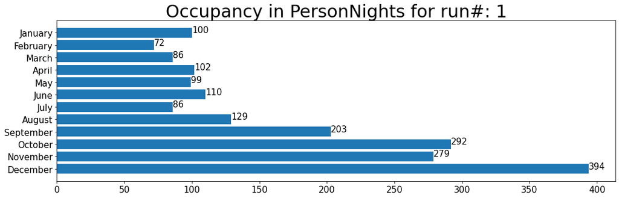

```python
# Prep the data - Occupancy over months
# =====================================

# occ_monthly1=run1
# occ_monthly2=run2
# occ_monthly3=run3

# occ_monthly1=occ_monthly1.assign(daily_occ= lambda x: (35-x['shelter_capacity_left']))
# occ_monthly2=occ_monthly2.assign(daily_occ= lambda x: (35-x['shelter_capacity_left']))
# occ_monthly3=occ_monthly3.assign(daily_occ= lambda x: (35-x['shelter_capacity_left']))

occ_monthly1 = occ_monthly1.groupby(["run_number", "month"]).agg(monthly_occupancy =("daily_occ", "sum"))
occ_monthly2 = occ_monthly2.groupby(["run_number", "month"]).agg(monthly_occupancy =("daily_occ", "sum"))
occ_monthly3 = occ_monthly3.groupby(["run_number", "month"]).agg(monthly_occupancy =("daily_occ", "sum"))

#.agg(min_height=('height', 'min')
#occ_monthly.rename_col_by_index(0,'monthly_occupancy')
#occ_monthly=occ_monthly.rename(columns={occ_monthly.columns[0]: 'monthly_occupancy'})
occ_monthly1.reset_index(inplace=True)
occ_monthly2.reset_index(inplace=True)
occ_monthly3.reset_index(inplace=True)

occ_monthlyall = pd.concat([occ_monthly1,occ_monthly2,occ_monthly3])

occ_months1=occ_monthlyall[(occ_monthlyall['run_number'] == 1)]
occ_months2=occ_monthlyall[(occ_monthlyall['run_number'] == 2)]
occ_months3=occ_monthlyall[(occ_monthlyall['run_number'] == 3)]


months = ["January", "February", "March", "April", "May", "June","July", "August", "September", "October", \
          "November", "December"]
occ_monthly1['month'] = pd.Categorical(occ_monthly1['month'], categories=months, ordered=True)
occ_monthly1=occ_monthly1.sort_values('month', ascending=False)
occ_monthly2['month'] = pd.Categorical(occ_monthly2['month'], categories=months, ordered=True)
occ_monthly2=occ_monthly2.sort_values('month', ascending=False)
occ_monthly3['month'] = pd.Categorical(occ_monthly3['month'], categories=months, ordered=True)
occ_monthly3=occ_monthly3.sort_values('month', ascending=False)
occ_monthly_mean = occ_monthlyall.groupby(["month"]).agg(monthly_occupancy =("monthly_occupancy", "mean"))
occ_monthly_mean['run_number']=0
occ_monthly_mean.reset_index(inplace=True)
occ_monthly_mean['month'] = pd.Categorical(occ_monthly_mean['month'], categories=months, ordered=True)
occ_monthly_mean=occ_monthly_mean.sort_values('month', ascending=False)




## Visualize - Over Months
# ========================

titlestr = 'Occupancy in PersonNights for run#: '+ str(occ_monthly1.loc[1,'run_number'])
plt.title(titlestr,fontsize=30)
plt.barh(occ_monthly1['month'],occ_monthly1['monthly_occupancy'])

for index, value in enumerate(occ_monthly1['monthly_occupancy']):
    plt.text(value, index,
             str(value))

plt.show()
```

## Mean Occupancy

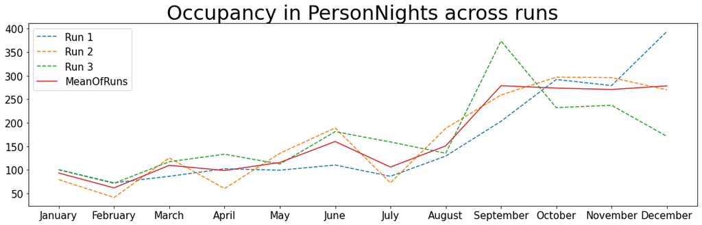

```python
## Visualize - Over Runs
# =======================

occ_monthly_mean=occ_monthly_mean.sort_values('month', ascending=True)
occ_monthly1=occ_monthly1.sort_values('month', ascending=True)
occ_monthly2=occ_monthly2.sort_values('month', ascending=True)
occ_monthly3=occ_monthly3.sort_values('month', ascending=True)


titlestr = 'Occupancy in PersonNights across runs'
plt.title(titlestr,fontsize=30)

plt.rcParams["figure.figsize"] = [15, 5]
plt.rcParams["figure.autolayout"] = True
#fig = plt.figure() # HINT: first uncomment it, it will print two graphs, one weird one.
#then comment and re-run it will just print 1 nice graph


plt.plot(occ_monthly1['month'], occ_monthly1['monthly_occupancy'], label = "Run 1", linestyle='dashed')
plt.plot(occ_monthly2['month'], occ_monthly2['monthly_occupancy'], label = "Run 2",linestyle='dashed')
plt.plot(occ_monthly3['month'], occ_monthly3['monthly_occupancy'], label = "Run 3",linestyle='dashed')
plt.plot(occ_monthly_mean['month'], occ_monthly_mean['monthly_occupancy'], label = "MeanOfRuns",ms=30)
occ_monthly_mean
plt.legend()
spacing = 0.100
fig.subplots_adjust(bottom=spacing)
plt.show()
```

## Surplus capacity over time

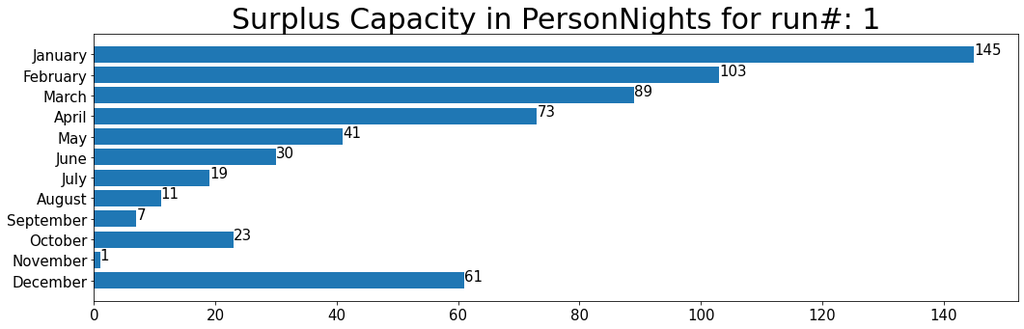

```python
# Prep the data - Surplus capacity over months
# ===========================================

spc_monthly1=run1
spc_monthly2=run2
spc_monthly3=run3

spc_monthly1 = spc_monthly1.groupby(["run_number", "month"]).agg(monthly_spc =("shelter_capacity_left", "sum"))
spc_monthly2 = spc_monthly2.groupby(["run_number", "month"]).agg(monthly_spc =("shelter_capacity_left", "sum"))
spc_monthly3 = spc_monthly3.groupby(["run_number", "month"]).agg(monthly_spc =("shelter_capacity_left", "sum"))


spc_monthly1.reset_index(inplace=True)
spc_monthly2.reset_index(inplace=True)
spc_monthly3.reset_index(inplace=True)

spc_monthlyall = pd.concat([spc_monthly1,spc_monthly2,spc_monthly3])

spc_months1=spc_monthlyall[(spc_monthlyall['run_number'] == 1)]
spc_months2=spc_monthlyall[(spc_monthlyall['run_number'] == 2)]
spc_months3=spc_monthlyall[(spc_monthlyall['run_number'] == 3)]


months = ["January", "February", "March", "April", "May", "June","July", "August", "September", "October", \
          "November", "December"]
spc_monthly1['month'] = pd.Categorical(spc_monthly1['month'], categories=months, ordered=True)
spc_monthly1=spc_monthly1.sort_values('month', ascending=False)
spc_monthly2['month'] = pd.Categorical(spc_monthly2['month'], categories=months, ordered=True)
spc_monthly2=spc_monthly2.sort_values('month', ascending=False)
spc_monthly3['month'] = pd.Categorical(spc_monthly3['month'], categories=months, ordered=True)
spc_monthly3=spc_monthly3.sort_values('month', ascending=False)
spc_monthly_mean = spc_monthlyall.groupby(["month"]).agg(monthly_spc =("monthly_spc", "mean"))
spc_monthly_mean['run_number']=0
spc_monthly_mean.reset_index(inplace=True)
spc_monthly_mean['month'] = pd.Categorical(spc_monthly_mean['month'], categories=months, ordered=True)
spc_monthly_mean=spc_monthly_mean.sort_values('month', ascending=False)


## Visualize - Over Months
# ========================

titlestr = 'Surplus Capacity in PersonNights for run#: '+ str(spc_monthly1.loc[1,'run_number'])
plt.title(titlestr,fontsize=30)
plt.barh(spc_monthly1['month'],spc_monthly1['monthly_spc'])

for index, value in enumerate(spc_monthly1['monthly_spc']):
    plt.text(value, index,
             str(value))

plt.show()
```

## mean surplus capacity

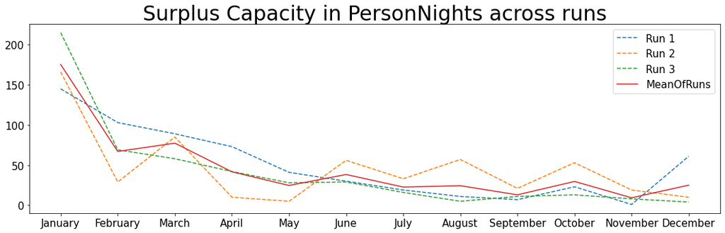

```python
## Visualize - Over Runs
# =======================

spc_monthly_mean=spc_monthly_mean.sort_values('month', ascending=True)
spc_monthly1=spc_monthly1.sort_values('month', ascending=True)
spc_monthly2=spc_monthly2.sort_values('month', ascending=True)
spc_monthly3=spc_monthly3.sort_values('month', ascending=True)

titlestr = 'Surplus Capacity in PersonNights across runs'
plt.title(titlestr,fontsize=30)

plt.rcParams["figure.figsize"] = [15, 5]
plt.rcParams["figure.autolayout"] = True
#fig = plt.figure()

plt.plot(spc_monthly1['month'], spc_monthly1['monthly_spc'], label = "Run 1", linestyle='dashed')
plt.plot(spc_monthly2['month'], spc_monthly2['monthly_spc'], label = "Run 2",linestyle='dashed')
plt.plot(spc_monthly3['month'], spc_monthly3['monthly_spc'], label = "Run 3",linestyle='dashed')
plt.plot(spc_monthly_mean['month'], spc_monthly_mean['monthly_spc'], label = "MeanOfRuns",ms=50)
occ_monthly_mean
plt.legend()
spacing = 0.100
fig.subplots_adjust(bottom=spacing)
plt.show()
```

## Abuse victims turned away

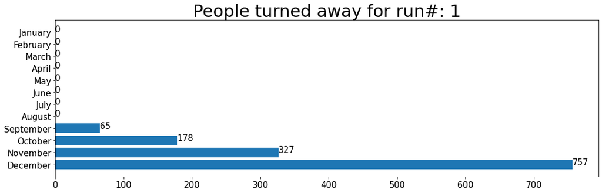

```python
# Prep the data - Abuse victims turned away over months
# ======================================================

avt_monthly1=run1
avt_monthly2=run2
avt_monthly3=run3

avt_monthly1 = avt_monthly1.groupby(["run_number", "month"]).agg(monthly_avt =("ppl_turned_away", "sum"))
avt_monthly2 = avt_monthly2.groupby(["run_number", "month"]).agg(monthly_avt =("ppl_turned_away", "sum"))
avt_monthly3 = avt_monthly3.groupby(["run_number", "month"]).agg(monthly_avt =("ppl_turned_away", "sum"))


avt_monthly1.reset_index(inplace=True)
avt_monthly2.reset_index(inplace=True)
avt_monthly3.reset_index(inplace=True)

avt_monthlyall = pd.concat([avt_monthly1,avt_monthly2,avt_monthly3])

avt_months1=avt_monthlyall[(avt_monthlyall['run_number'] == 1)]
avt_months2=avt_monthlyall[(avt_monthlyall['run_number'] == 2)]
avt_months3=avt_monthlyall[(avt_monthlyall['run_number'] == 3)]


months = ["January", "February", "March", "April", "May", "June","July", "August", "September", "October", \
          "November", "December"]
avt_monthly1['month'] = pd.Categorical(avt_monthly1['month'], categories=months, ordered=True)
avt_monthly1=avt_monthly1.sort_values('month', ascending=False)
avt_monthly2['month'] = pd.Categorical(avt_monthly2['month'], categories=months, ordered=True)
avt_monthly2=avt_monthly2.sort_values('month', ascending=False)
avt_monthly3['month'] = pd.Categorical(avt_monthly3['month'], categories=months, ordered=True)
avt_monthly3=avt_monthly3.sort_values('month', ascending=False)
avt_monthly_mean = avt_monthlyall.groupby(["month"]).agg(monthly_avt =("monthly_avt", "mean"))
avt_monthly_mean['run_number']=0
avt_monthly_mean.reset_index(inplace=True)
avt_monthly_mean['month'] = pd.Categorical(avt_monthly_mean['month'], categories=months, ordered=True)
avt_monthly_mean=avt_monthly_mean.sort_values('month', ascending=False)


## Visualize - Over Months
# ========================

titlestr = 'People turned away for run#: '+ str(avt_monthly1.loc[1,'run_number'])
plt.title(titlestr,fontsize=30)
plt.barh(avt_monthly1['month'],avt_monthly1['monthly_avt'])

for index, value in enumerate(avt_monthly1['monthly_avt']):
    plt.text(value, index,
             str(value))

plt.show()
```

## Mean number of abuse victims turned away

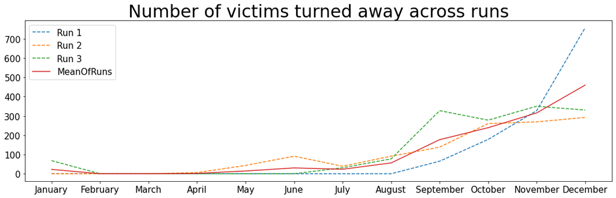

```python
## Visualize - Over Runs
# =======================

avt_monthly_mean=avt_monthly_mean.sort_values('month', ascending=True)
avt_monthly1=avt_monthly1.sort_values('month', ascending=True)
avt_monthly2=avt_monthly2.sort_values('month', ascending=True)
avt_monthly3=avt_monthly3.sort_values('month', ascending=True)

titlestr = 'Number of victims turned away across runs'
plt.title(titlestr,fontsize=30)

plt.rcParams["figure.figsize"] = [15, 5]
plt.rcParams["figure.autolayout"] = True
#fig = plt.figure()

plt.plot(avt_monthly1['month'], avt_monthly1['monthly_avt'], label = "Run 1", linestyle='dashed')
plt.plot(avt_monthly2['month'], avt_monthly2['monthly_avt'], label = "Run 2",linestyle='dashed')
plt.plot(avt_monthly3['month'], avt_monthly3['monthly_avt'], label = "Run 3",linestyle='dashed')
plt.plot(avt_monthly_mean['month'], avt_monthly_mean['monthly_avt'], label = "MeanOfRuns",ms=50)
plt.legend()
spacing = 0.100
fig.subplots_adjust(bottom=spacing)
plt.show()
```

## victims sent to hotels

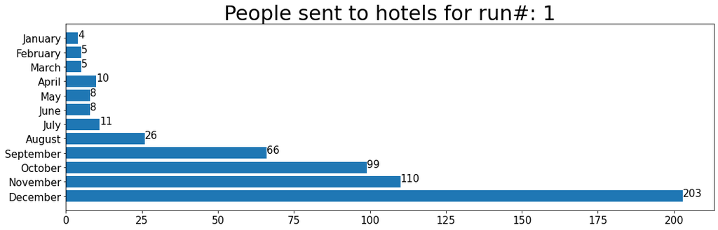

```python
# Prep the data - Abuse victims turned away over months
# ======================================================

vsh_monthly1=run1
vsh_monthly2=run2
vsh_monthly3=run3

vsh_monthly1 = vsh_monthly1.groupby(["run_number", "month"]).agg(monthly_vsh =("sent_to_hotel", "sum"))
vsh_monthly2 = vsh_monthly2.groupby(["run_number", "month"]).agg(monthly_vsh =("sent_to_hotel", "sum"))
vsh_monthly3 = vsh_monthly3.groupby(["run_number", "month"]).agg(monthly_vsh =("sent_to_hotel", "sum"))


vsh_monthly1.reset_index(inplace=True)
vsh_monthly2.reset_index(inplace=True)
vsh_monthly3.reset_index(inplace=True)

vsh_monthlyall = pd.concat([vsh_monthly1,vsh_monthly2,vsh_monthly3])

vsh_months1=vsh_monthlyall[(vsh_monthlyall['run_number'] == 1)]
vsh_months2=vsh_monthlyall[(vsh_monthlyall['run_number'] == 2)]
vsh_months3=vsh_monthlyall[(vsh_monthlyall['run_number'] == 3)]


months = ["January", "February", "March", "April", "May", "June","July", "August", "September", "October", \
          "November", "December"]
vsh_monthly1['month'] = pd.Categorical(vsh_monthly1['month'], categories=months, ordered=True)
vsh_monthly1=vsh_monthly1.sort_values('month', ascending=False)
vsh_monthly2['month'] = pd.Categorical(vsh_monthly2['month'], categories=months, ordered=True)
vsh_monthly2=vsh_monthly2.sort_values('month', ascending=False)
vsh_monthly3['month'] = pd.Categorical(vsh_monthly3['month'], categories=months, ordered=True)
vsh_monthly3=vsh_monthly3.sort_values('month', ascending=False)
vsh_monthly_mean = vsh_monthlyall.groupby(["month"]).agg(monthly_vsh =("monthly_vsh", "mean"))
vsh_monthly_mean['run_number']=0
vsh_monthly_mean.reset_index(inplace=True)
vsh_monthly_mean['month'] = pd.Categorical(vsh_monthly_mean['month'], categories=months, ordered=True)
vsh_monthly_mean=vsh_monthly_mean.sort_values('month', ascending=False)


## Visualize - Over Months
# ========================

titlestr = 'People sent to hotels for run#: '+ str(vsh_monthly1.loc[1,'run_number'])
plt.title(titlestr,fontsize=30)
plt.barh(vsh_monthly1['month'],vsh_monthly1['monthly_vsh'])

for index, value in enumerate(vsh_monthly1['monthly_vsh']):
    plt.text(value, index,
             str(value))

plt.show()
```

## mean number of victims sent to hotels

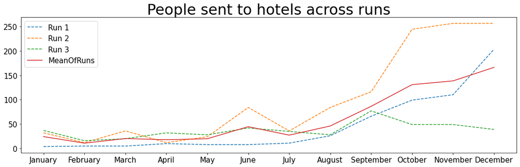

```python
## Visualize - Over Runs
# =======================


vsh_monthly_mean=vsh_monthly_mean.sort_values('month', ascending=True)
vsh_monthly1=vsh_monthly1.sort_values('month', ascending=True)
vsh_monthly2=vsh_monthly2.sort_values('month', ascending=True)
vsh_monthly3=vsh_monthly3.sort_values('month', ascending=True)

titlestr = 'People sent to hotels across runs'
plt.title(titlestr,fontsize=30)

plt.rcParams["figure.figsize"] = [15, 5]
plt.rcParams["figure.autolayout"] = True
#fig = plt.figure()

plt.plot(vsh_monthly1['month'], vsh_monthly1['monthly_vsh'], label = "Run 1", linestyle='dashed')
plt.plot(vsh_monthly2['month'], vsh_monthly2['monthly_vsh'], label = "Run 2",linestyle='dashed')
plt.plot(vsh_monthly3['month'], vsh_monthly3['monthly_vsh'], label = "Run 3",linestyle='dashed')
plt.plot(vsh_monthly_mean['month'], vsh_monthly_mean['monthly_vsh'], label = "MeanOfRuns",ms=50)
plt.legend()
spacing = 0.100
fig.subplots_adjust(bottom=spacing)
plt.show()
```

## NHPP implementation for incoming clients

This is actually working NHPP code. While we didn't integrate this into our model above, this is part of the future todo list

The work that is required here is to convert this one run model to a more real-time model. Currently this code runs once and generates all the incoming arrivals all together. However, our code requires a more real-time update, in that the code wants to call a function and a real-time "stay_duration". That is the extra work needed here.

```python
## Lets assume the average number of entries in the shelter on non-holiday season is 20 and holiday season is 30
## Each entry could be between 1 to 4 women arriving at shelter
#defining non-homogenous poison process with arrival rates varying between 1 to 4 in the day
def nhpp_arrival():
    t = 0
    potential_arr_time = 0
    arrival_times = []
    arrival_rate = []

  #defining a period function where arrival rate varies from 1 to 4
    ld = 3.5 + 2.5*math.sin(t/2)

  #max_arrivals
    ld_0 = 6

    for month in range(1,12):
        if (month <= 8):
            n = 20
        else:
            n = 30

        #generates arrival for each month
        for i in range(0,n):
            ld = 3.5 + 2.5*math.sin(t/2)

            #generate a uniform sample
            U = random.uniform(0,1)

            #calculating exponential arrival time
            potential_intr_arr = -1/ld_0 * math.log(U)

            #bootstraping to get arrival times for each arrival
            potential_arr_time += potential_intr_arr

            #assign the new arrival time to t
            t = potential_arr_time

            #generate a uniform to test the probability of accepting or rejecting the potential arrival (Thinning algorithm)
            V =  random.uniform(0,1)
            prob = ld / ld_0

       #accept t if V < prob
            if V <= prob:
                 arrival_times.append(t)
            i+=1

    for j in range(0,len(arrival_times)):
        x = 3.5 + 2.5*math.sin(arrival_times[j]/2)
        arrival_rate.append(x)

    #generate client type for each arrival
    client_type = list(np.random.choice([1,2,3,4],len(arrival_times), p=[0.25,0.25,0.25,0.25]))

    return(arrival_times,arrival_rate,client_type)
```

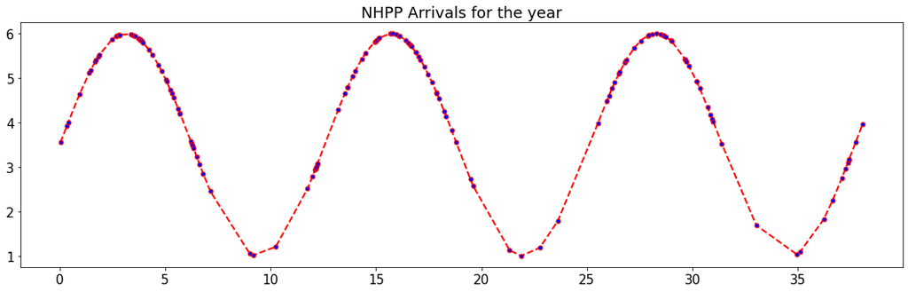

```python
# Arrivals on a weekday:
arrival_times,arrival_rate,client_type = nhpp_arrival()

# plotting the arrival rates at each arrival time ---> non-homogeneous poisson process
plt.plot(arrival_times,arrival_rate, color='red', linestyle='dashed', linewidth = 2,
         marker='o', markerfacecolor='blue', markersize=5 )
plt.title('NHPP Arrivals for the year')
```

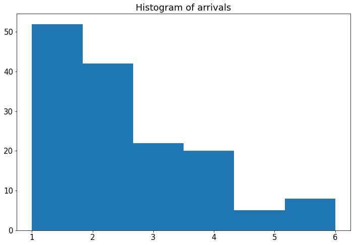

```python
# round off arrivals
fig, ax = plt.subplots(figsize =(10, 7))
# mirror the arrivals to make it skewed for smaller arrivals compared to larger ones (can be removed if needed)
ax.hist([7-round(i) for i in arrival_rate],bins=6)
plt.title('Histogram of arrivals')
```

#### References :

##### https://hpaulkeeler.com/simulating-an-inhomogeneous-poisson-point-process/

##### https://stackoverflow.com/questions/32712409/how-to-sample-inhomogeneous-poisson-processes-in-python-faster-than-this

##### The original bones of this simpy model is Inspired by car wash example https://simpy.readthedocs.io/en/latest/examples/carwash.html